# ICE Detention Facility Statistics

# Adams County Det Center

### ICE Detention Facility Statistical Report

*Data as of June 9, 2025*

## Key Statistics

| Facility Metric | Value |
| --- | --- |
| Address | 20 Hobo Fork Rd., Natchez, MS 39120 |
| Total Average Daily Population | 2,166 |
| Average Length of Stay | 50 days |
| Male Population | 2,166 |
| Female Population | 0 |
| Criminal Population | 30 |
| Non-Criminal Population | 2,136 |
| Facility Type | DIGSA |
| Area of Responsibility | NOL |
| Guaranteed Minimum | 1100 |

## Facility Location

[interactive chart not shown]

## Interval Average Daily Population

This is a backward moving average calculation of facility populations based on ICE data. For more information, see the background paper [here](https://relevant-research.com/work).

[figure not shown]

## Reported Average Daily Population

ICE reports facility populations, including disaggregations by gender and criminality, as cumulative averages over the entire fiscal year. We call this Reported ADP.

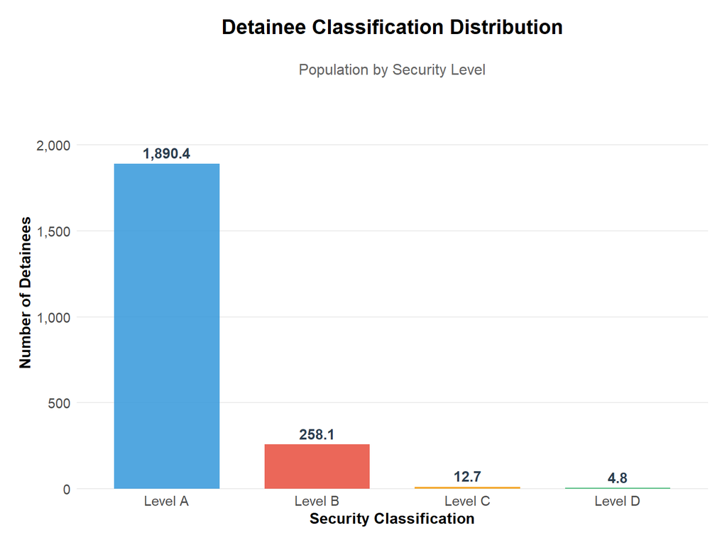

ICE defines these classifications as follows: “Upon admission and periodically thereafter, detainees are categorized into a security level based on a variety of public safety factors, and are housed accordingly. Factors include prior convictions, threat risk, disciplinary record, special vulnerabilities, and special management concerns. Detainees are categorized into one of four classes of security risk: A/low, B/medium low, C/medium high, and D/high.”

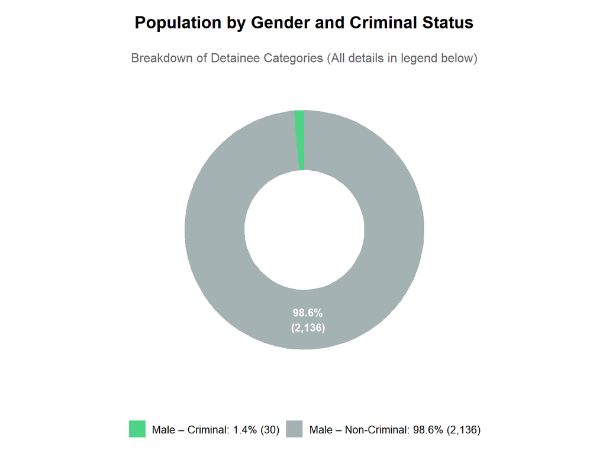

ICE defines criminality as follows:

- Convicted Criminal:
  - Immigration Violators with a criminal conviction entered into ICE systems of record at the time of ICE custody.
- Pending Criminal Charges:
  - Immigration Violators with pending criminal charges entered into ICE system of record at the time of ICE custody.
- Other Immigration Violators:
  - Immigration Violators without any known or a criminal conviction, or pending charges entered into ICE system of record at the time of ICE custody.”

*Report generated on July 02, 2025 using ICE Integrated Decision Support (IIDS) data from June 9, 2025*